# Exploratory Data Analysis

Shivam Verma

16/01/2020

## Description of the variables, [source](https://archive.ics.uci.edu/ml/datasets/Online+Shoppers+Purchasing+Intention+Dataset)

- “Administrative”, “Administrative Duration”, “Informational”, “Informational Duration”, “Product Related” and “Product Related Duration” represent the number of different types of pages visited by the visitor in that session and total time spent in each of these page categories. The values of these features are derived from the URL information of the pages visited by the user and updated in real time when a user takes an action, e.g. moving from one page to another.
- The “Bounce Rate”, “Exit Rate” and “Page Value” features represent the metrics measured by “Google Analytics” for each page in the e-commerce site.
- The value of “Bounce Rate” feature for a web page refers to the percentage of visitors who enter the site from that page and then leave (“bounce”) without triggering any other requests to the analytics server during that session.
- The value of “Exit Rate” feature for a specific web page is calculated as for all pageviews to the page, the percentage that were the last in the session.
- The “Page Value” feature represents the average value for a web page that a user visited before completing an e-commerce transaction.
- The “Special Day” feature indicates the closeness of the site visiting time to a specific special day (e.g. Mother’s Day, Valentine’s Day) in which the sessions are more likely to be finalized with transaction. The value of this attribute is determined by considering the dynamics of e-commerce such as the duration between the order date and delivery date. For example, for Valentina’s day, this value takes a nonzero value between February 2 and February 12, zero before and after this date unless it is close to another special day, and its maximum value of 1 on February 8.
- The dataset also includes operating system, browser, region, traffic type, visitor type as returning or new visitor, a Boolean value indicating whether the date of the visit is weekend, and month of the year.

```r
# need to source this from the script that fetches data
mydata <- fread("C:/Users/Shivam/Downloads/online_shoppers_intention.csv")

num_vars_1 <- c("Administrative", "Informational", "ProductRelated")
num_vars_2 <- c("Administrative_Duration", "Informational_Duration", "ProductRelated_Duration", "BounceRates", "ExitRates", "PageValues", "ProductRelated")
target <- "Revenue"
cat_vars <- setdiff(names(mydata), c(num_vars_1, num_vars_2, target))

ggplotly(ggplot(mydata, aes(Administrative)) + geom_histogram(binwidth = 1))
```

[interactive chart not shown]

```r
ggplotly(ggplot(mydata, aes(Informational)) + geom_histogram(binwidth = 1))
```

[interactive chart not shown]

```r
ggplotly(ggplot(mydata, aes(ProductRelated)) + geom_histogram(binwidth = 1))
```

[interactive chart not shown]

## Summary of Numeric Variables

```r
quantile_dist <- sapply(num_vars_2, FUN=function(x) {
  print(paste("Mean of", x, "is", round(mydata[, mean(get(x))], digits=3), "and standard deviation is", round(mydata[, sd(get(x))], digits=3)))
  mydata[, round(quantile(get(x), probs=seq(0,1,0.05)), digits=3)]
})
```

```
## [1] "Mean of Administrative_Duration is 80.819 and standard deviation is 176.779"
## [1] "Mean of Informational_Duration is 34.472 and standard deviation is 140.749"
## [1] "Mean of ProductRelated_Duration is 1194.746 and standard deviation is 1913.669"
## [1] "Mean of BounceRates is 0.022 and standard deviation is 0.048"
## [1] "Mean of ExitRates is 0.043 and standard deviation is 0.049"
## [1] "Mean of PageValues is 5.889 and standard deviation is 18.568"
## [1] "Mean of ProductRelated is 31.731 and standard deviation is 44.476"
```

```r
print(quantile_dist)
```

```
##      Administrative_Duration Informational_Duration
## 0%                     0.000                  0.000
## 5%                     0.000                  0.000
## 10%                    0.000                  0.000
## 15%                    0.000                  0.000
## 20%                    0.000                  0.000
## 25%                    0.000                  0.000
## 30%                    0.000                  0.000
## 35%                    0.000                  0.000
## 40%                    0.000                  0.000
## 45%                    0.000                  0.000
## 50%                    7.500                  0.000
## 55%                   22.000                  0.000
## 60%                   37.000                  0.000
## 65%                   53.160                  0.000
## 70%                   71.200                  0.000
## 75%                   93.256                  0.000
## 80%                  121.425                  0.000
## 85%                  162.497                 25.500
## 90%                  224.888                 72.000
## 95%                  348.266                195.000
## 100%                3398.750               2549.375
##      ProductRelated_Duration BounceRates ExitRates PageValues
## 0%                     0.000       0.000     0.000      0.000
## 5%                     0.000       0.000     0.005      0.000
## 10%                   36.000       0.000     0.007      0.000
## 15%                   77.000       0.000     0.010      0.000
## 20%                  129.000       0.000     0.012      0.000
## 25%                  184.137       0.000     0.014      0.000
## 30%                  246.980       0.000     0.016      0.000
## 35%                  317.094       0.000     0.018      0.000
## 40%                  402.117       0.000     0.021      0.000
## 45%                  493.308       0.000     0.023      0.000
## 50%                  598.937       0.003     0.025      0.000
## 55%                  716.612       0.005     0.029      0.000
## 60%                  852.000       0.007     0.033      0.000
## 65%                 1026.233       0.010     0.037      0.000
## 70%                 1227.014       0.013     0.041      0.000
## 75%                 1464.157       0.017     0.050      0.000
## 80%                 1775.929       0.023     0.058      3.060
```

[output cut: 11 more lines]

```
## 30%               9
## 35%              11
## 40%              13
## 45%              15
## 50%              18
## 55%              21
## 60%              24
## 65%              28
## 70%              32
## 75%              38
## 80%              45
## 85%              57
## 90%              74
## 95%             109
## 100%            705
```

## Percentage of rows for categories of categorical variables

```r
# Percentage of rows for categories of categorical variables
sapply(c(cat_vars, target), FUN=function(x) {
  round(mydata[, table(get(x))]/nrow(mydata), digits=3)*100
})
```

```
## $SpecialDay
##
##    0  0.2  0.4  0.6  0.8    1
## 89.9  1.4  2.0  2.8  2.6  1.2
##
## $Month
##
##  Aug  Dec  Feb  Jul June  Mar  May  Nov  Oct  Sep
##  3.5 14.0  1.5  3.5  2.3 15.5 27.3 24.3  4.5  3.6
##
## $OperatingSystems
##
##    1    2    3    4    5    6    7    8
## 21.0 53.5 20.7  3.9  0.0  0.2  0.1  0.6
##
## $Browser
##
##    1    2    3    4    5    6    7    8    9   10   11   12   13
## 20.0 64.6  0.9  6.0  3.8  1.4  0.4  1.1  0.0  1.3  0.0  0.1  0.5
##
## $Region
##
##    1    2    3    4    5    6    7    8    9
## 38.8  9.2 19.5  9.6  2.6  6.5  6.2  3.5  4.1
##
## $TrafficType
##
##    1    2    3    4    5    6    7    8    9   10   11   12   13   14   15
## 19.9 31.7 16.6  8.7  2.1  3.6  0.3  2.8  0.3  3.6  2.0  0.0  6.0  0.1  0.3
##   16   17   18   19   20
##  0.0  0.0  0.1  0.1  1.6
##
## $VisitorType
##
##       New_Visitor             Other Returning_Visitor
##              13.7               0.7              85.6
##
## $Weekend
##
## FALSE  TRUE
##  76.7  23.3
##
## $Revenue
##
## FALSE  TRUE
##  84.5  15.5
```

## Target vs Other Variables

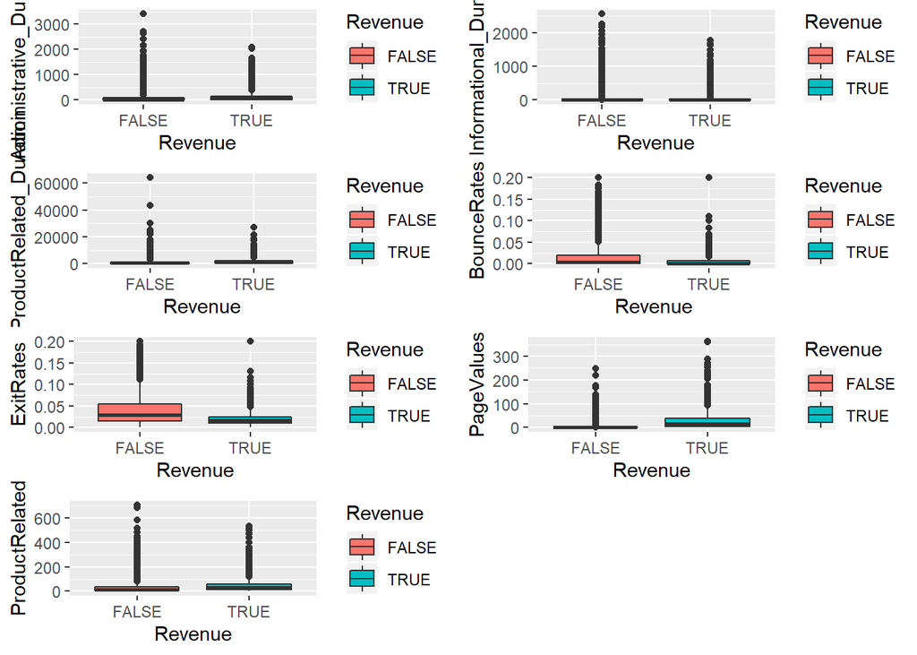

```r
chart1 <- ggplot(mydata, aes(Revenue, Administrative_Duration, fill=Revenue)) + geom_boxplot()
chart2 <- ggplot(mydata, aes(Revenue, Informational_Duration, fill=Revenue)) + geom_boxplot()
chart3 <- ggplot(mydata, aes(Revenue, ProductRelated_Duration, fill=Revenue)) + geom_boxplot()
chart4 <- ggplot(mydata, aes(Revenue, BounceRates, fill=Revenue)) + geom_boxplot()
chart5 <- ggplot(mydata, aes(Revenue, ExitRates, fill=Revenue)) + geom_boxplot()
chart6 <- ggplot(mydata, aes(Revenue, PageValues, fill=Revenue)) + geom_boxplot()
chart7 <- ggplot(mydata, aes(Revenue, ProductRelated, fill=Revenue)) + geom_boxplot()

plot_grid(chart1, chart2, chart3, chart4, chart5, chart6, chart7, nrow=4)
```

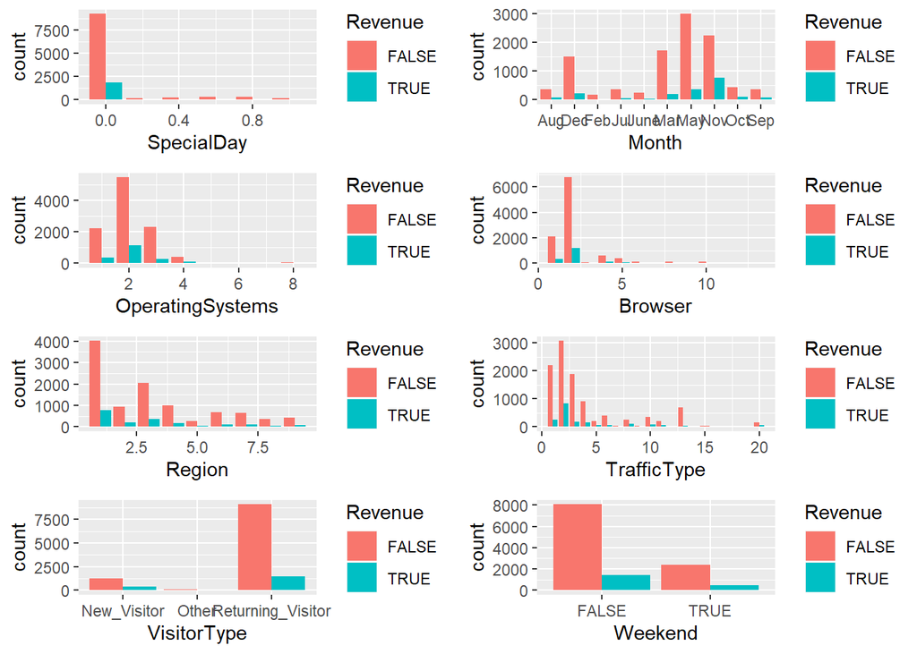

```r
chart_a <- ggplot(mydata, aes(SpecialDay, fill=Revenue)) + geom_bar(stat = "count", position = "dodge")
chart_b <- ggplot(mydata, aes(Month, fill=Revenue)) + geom_bar(stat = "count", position = "dodge")
chart_c <- ggplot(mydata, aes(OperatingSystems, fill=Revenue)) + geom_bar(stat = "count", position = "dodge")
chart_d <- ggplot(mydata, aes(Browser, fill=Revenue)) + geom_bar(stat = "count", position = "dodge")
chart_e <- ggplot(mydata, aes(Region, fill=Revenue)) + geom_bar(stat = "count", position = "dodge")
chart_f <- ggplot(mydata, aes(TrafficType, fill=Revenue)) + geom_bar(stat = "count", position = "dodge")
chart_g <- ggplot(mydata, aes(VisitorType, fill=Revenue)) + geom_bar(stat = "count", position = "dodge")
chart_h <- ggplot(mydata, aes(Weekend, fill=Revenue)) + geom_bar(stat = "count", position = "dodge")

options(repr.plot.width = 20, repr.plot.height = 8)
plot_grid(chart_a, chart_b, chart_c, chart_d, chart_e, chart_f, chart_g, chart_h, nrow=4)
```

```r
#temp <- sapply(num_vars_1, FUN=function(x) {
#  ggplotly(ggplot(mydata, aes(get(x))) + geom_histogram(binwidth = 1))
#})
#temp

#test_fun <- function() {
#  ggplotly(ggplot(mydata, aes(get(x))) + geom_histogram(binwidth = 1))
#}

#for (x in num_vars_1){
#  test_fun()
#}
```